# Risk Factor Analysis

## Outcome Variable

**Outcome Variable:** sstunted

## Predictor Variables

**Intervention Variable:** earlybf

**Adjustment Set:**

unadjusted

## Stratifying Variables

The analysis was stratified on these variable(s):

- agecat
- studyid
- country

## Data Summary

| agecat | studyid | country | earlybf | sstunted | n_cell | n |
| --- | --- | --- | --- | --- | --- | --- |
| Birth | ki0047075b-MAL-ED | BANGLADESH | 0 | 0 | 90 | 256 |
| Birth | ki0047075b-MAL-ED | BANGLADESH | 0 | 1 | 7 | 256 |
| Birth | ki0047075b-MAL-ED | BANGLADESH | 1 | 0 | 157 | 256 |
| Birth | ki0047075b-MAL-ED | BANGLADESH | 1 | 1 | 2 | 256 |
| Birth | ki0047075b-MAL-ED | BRAZIL | 0 | 0 | 104 | 191 |
| Birth | ki0047075b-MAL-ED | BRAZIL | 0 | 1 | 4 | 191 |
| Birth | ki0047075b-MAL-ED | BRAZIL | 1 | 0 | 79 | 191 |
| Birth | ki0047075b-MAL-ED | BRAZIL | 1 | 1 | 4 | 191 |
| Birth | ki0047075b-MAL-ED | INDIA | 0 | 0 | 77 | 205 |
| Birth | ki0047075b-MAL-ED | INDIA | 0 | 1 | 4 | 205 |
| Birth | ki0047075b-MAL-ED | INDIA | 1 | 0 | 121 | 205 |
| Birth | ki0047075b-MAL-ED | INDIA | 1 | 1 | 3 | 205 |
| Birth | ki0047075b-MAL-ED | NEPAL | 0 | 0 | 90 | 173 |
| Birth | ki0047075b-MAL-ED | NEPAL | 0 | 1 | 4 | 173 |
| Birth | ki0047075b-MAL-ED | NEPAL | 1 | 0 | 77 | 173 |
| Birth | ki0047075b-MAL-ED | NEPAL | 1 | 1 | 2 | 173 |
| Birth | ki0047075b-MAL-ED | PERU | 0 | 0 | 68 | 287 |
| Birth | ki0047075b-MAL-ED | PERU | 0 | 1 | 5 | 287 |
| Birth | ki0047075b-MAL-ED | PERU | 1 | 0 | 211 | 287 |
| Birth | ki0047075b-MAL-ED | PERU | 1 | 1 | 3 | 287 |
| Birth | ki0047075b-MAL-ED | SOUTH AFRICA | 0 | 0 | 91 | 247 |
| Birth | ki0047075b-MAL-ED | SOUTH AFRICA | 0 | 1 | 1 | 247 |
| Birth | ki0047075b-MAL-ED | SOUTH AFRICA | 1 | 0 | 155 | 247 |
| Birth | ki0047075b-MAL-ED | SOUTH AFRICA | 1 | 1 | 0 | 247 |
| Birth | ki0047075b-MAL-ED | TANZANIA, UNITED REPUBLIC OF | 0 | 0 | 10 | 123 |
| Birth | ki0047075b-MAL-ED | TANZANIA, UNITED REPUBLIC OF | 0 | 1 | 2 | 123 |
| Birth | ki0047075b-MAL-ED | TANZANIA, UNITED REPUBLIC OF | 1 | 0 | 107 | 123 |
| Birth | ki0047075b-MAL-ED | TANZANIA, UNITED REPUBLIC OF | 1 | 1 | 4 | 123 |
| Birth | ki1000109-EE | PAKISTAN | 0 | 0 | 2 | 4 |
| Birth | ki1000109-EE | PAKISTAN | 0 | 1 | 0 | 4 |

[output cut: 126 more lines]

The following strata were considered:

- agecat: 24 months, studyid: ki0047075b-MAL-ED, country: BANGLADESH
- agecat: 24 months, studyid: ki0047075b-MAL-ED, country: BRAZIL
- agecat: 24 months, studyid: ki0047075b-MAL-ED, country: INDIA
- agecat: 24 months, studyid: ki0047075b-MAL-ED, country: NEPAL
- agecat: 24 months, studyid: ki0047075b-MAL-ED, country: PERU
- agecat: 24 months, studyid: ki0047075b-MAL-ED, country: SOUTH AFRICA
- agecat: 24 months, studyid: ki0047075b-MAL-ED, country: TANZANIA, UNITED REPUBLIC OF
- agecat: 24 months, studyid: ki1017093c-NIH-Crypto, country: BANGLADESH
- agecat: 24 months, studyid: ki1113344-GMS-Nepal, country: NEPAL
- agecat: 24 months, studyid: ki1126311-ZVITAMBO, country: ZIMBABWE
- agecat: 24 months, studyid: kiGH5241-JiVitA-3, country: BANGLADESH
- agecat: 24 months, studyid: kiGH5241-JiVitA-4, country: BANGLADESH
- agecat: 6 months, studyid: ki0047075b-MAL-ED, country: BANGLADESH
- agecat: 6 months, studyid: ki0047075b-MAL-ED, country: BRAZIL
- agecat: 6 months, studyid: ki0047075b-MAL-ED, country: INDIA
- agecat: 6 months, studyid: ki0047075b-MAL-ED, country: NEPAL
- agecat: 6 months, studyid: ki0047075b-MAL-ED, country: PERU
- agecat: 6 months, studyid: ki0047075b-MAL-ED, country: SOUTH AFRICA
- agecat: 6 months, studyid: ki0047075b-MAL-ED, country: TANZANIA, UNITED REPUBLIC OF
- agecat: 6 months, studyid: ki1000109-EE, country: PAKISTAN
- agecat: 6 months, studyid: ki1000304b-SAS-CompFeed, country: INDIA
- agecat: 6 months, studyid: ki1017093c-NIH-Crypto, country: BANGLADESH
- agecat: 6 months, studyid: ki1113344-GMS-Nepal, country: NEPAL
- agecat: 6 months, studyid: ki1126311-ZVITAMBO, country: ZIMBABWE
- agecat: 6 months, studyid: kiGH5241-JiVitA-3, country: BANGLADESH
- agecat: 6 months, studyid: kiGH5241-JiVitA-4, country: BANGLADESH
- agecat: Birth, studyid: ki0047075b-MAL-ED, country: BANGLADESH
- agecat: Birth, studyid: ki0047075b-MAL-ED, country: BRAZIL
- agecat: Birth, studyid: ki0047075b-MAL-ED, country: INDIA
- agecat: Birth, studyid: ki0047075b-MAL-ED, country: NEPAL
- agecat: Birth, studyid: ki0047075b-MAL-ED, country: PERU
- agecat: Birth, studyid: ki0047075b-MAL-ED, country: SOUTH AFRICA
- agecat: Birth, studyid: ki0047075b-MAL-ED, country: TANZANIA, UNITED REPUBLIC OF
- agecat: Birth, studyid: ki1000109-EE, country: PAKISTAN
- agecat: Birth, studyid: ki1000304b-SAS-CompFeed, country: INDIA
- agecat: Birth, studyid: ki1017093c-NIH-Crypto, country: BANGLADESH
- agecat: Birth, studyid: ki1126311-ZVITAMBO, country: ZIMBABWE
- agecat: Birth, studyid: kiGH5241-JiVitA-3, country: BANGLADESH
- agecat: Birth, studyid: kiGH5241-JiVitA-4, country: BANGLADESH

### Dropped Strata

Some strata were dropped due to rare outcomes:

- agecat: Birth, studyid: ki0047075b-MAL-ED, country: BANGLADESH
- agecat: Birth, studyid: ki0047075b-MAL-ED, country: BRAZIL
- agecat: Birth, studyid: ki0047075b-MAL-ED, country: INDIA
- agecat: Birth, studyid: ki0047075b-MAL-ED, country: NEPAL
- agecat: Birth, studyid: ki0047075b-MAL-ED, country: PERU
- agecat: Birth, studyid: ki0047075b-MAL-ED, country: SOUTH AFRICA
- agecat: Birth, studyid: ki0047075b-MAL-ED, country: TANZANIA, UNITED REPUBLIC OF
- agecat: Birth, studyid: ki1000109-EE, country: PAKISTAN
- agecat: Birth, studyid: ki1000304b-SAS-CompFeed, country: INDIA
- agecat: Birth, studyid: ki1017093c-NIH-Crypto, country: BANGLADESH
- agecat: 6 months, studyid: ki0047075b-MAL-ED, country: BANGLADESH
- agecat: 6 months, studyid: ki0047075b-MAL-ED, country: BRAZIL
- agecat: 6 months, studyid: ki0047075b-MAL-ED, country: INDIA
- agecat: 6 months, studyid: ki0047075b-MAL-ED, country: NEPAL
- agecat: 6 months, studyid: ki0047075b-MAL-ED, country: PERU
- agecat: 6 months, studyid: ki0047075b-MAL-ED, country: SOUTH AFRICA
- agecat: 6 months, studyid: ki1017093c-NIH-Crypto, country: BANGLADESH
- agecat: 24 months, studyid: ki0047075b-MAL-ED, country: BRAZIL
- agecat: 24 months, studyid: ki0047075b-MAL-ED, country: NEPAL
- agecat: 24 months, studyid: ki0047075b-MAL-ED, country: PERU
- agecat: 24 months, studyid: ki1017093c-NIH-Crypto, country: BANGLADESH
- agecat: 24 months, studyid: kiGH5241-JiVitA-3, country: BANGLADESH

## Methods Detail

We’re interested in the causal parameters $E[Y_a]$ for all values of $a \in \mathcal{A}$. These parameters represent the mean outcome if, possibly contrary to fact, we intervened to set all units to have $A=a$. Under the randomization and positivity assumptions, these are identified by the statistical parameters $\psi_a=E_W[E_{Y|A,W}(Y|A=a,W)]$. In addition, we’re interested in the mean of $Y$, $E[Y]$ under no intervention (the observed mean). We will estimate these parameters by using SuperLearner to fit the relevant likelihood factors – $E_{Y|A,W}(Y|A=a,W)$ and $p(A=a|W)$, and then updating our likelihood fit using a joint TMLE.

For unadjusted analyses ($W=\{\}$), initial likelihoods were estimated using Lrnr_glm to estimate the simple $E(Y|A)$ and Lrnr_mean to estimate $p(A)$. For adjusted analyses, a small library containing Lrnr_glmnet, Lrnr_xgboost, and Lrnr_mean was used.

Having estimated these parameters, we will then use the delta method to estimate relative risks and attributable risks relative to a prespecified baseline level of $A$.

# Results Detail

## Results Plots

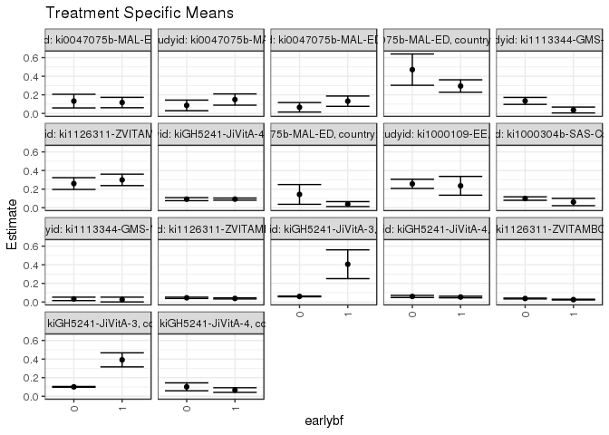

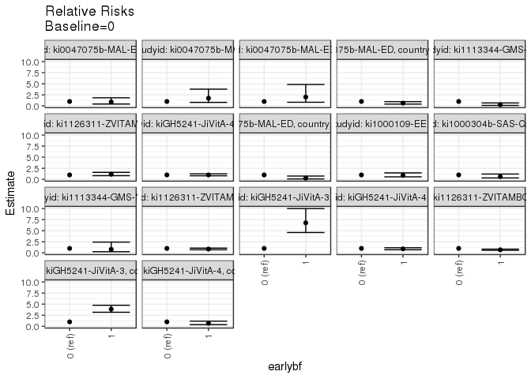

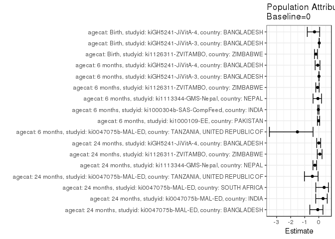

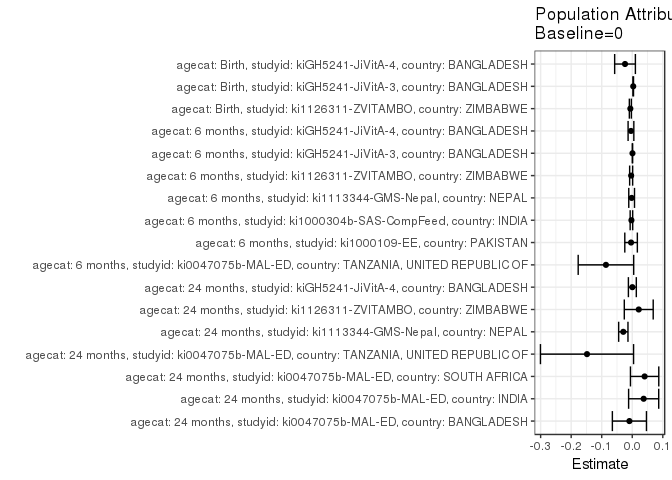

## Results Table

### Parameter: TSM

| agecat | studyid | country | intervention_level | baseline_level | estimate | ci_lower | ci_upper |
| --- | --- | --- | --- | --- | --- | --- | --- |
| Birth | ki1126311-ZVITAMBO | ZIMBABWE | 0 | NA | 0.0375043 | 0.0326086 | 0.0424000 |
| Birth | ki1126311-ZVITAMBO | ZIMBABWE | 1 | NA | 0.0257156 | 0.0218772 | 0.0295540 |
| Birth | kiGH5241-JiVitA-3 | BANGLADESH | 0 | NA | 0.1010399 | 0.0963710 | 0.1057088 |
| Birth | kiGH5241-JiVitA-3 | BANGLADESH | 1 | NA | 0.3915094 | 0.3156688 | 0.4673501 |
| Birth | kiGH5241-JiVitA-4 | BANGLADESH | 0 | NA | 0.1015625 | 0.0587995 | 0.1443255 |
| Birth | kiGH5241-JiVitA-4 | BANGLADESH | 1 | NA | 0.0671378 | 0.0420820 | 0.0921936 |
| 6 months | ki0047075b-MAL-ED | TANZANIA, UNITED REPUBLIC OF | 0 | NA | 0.1428571 | 0.0368142 | 0.2489001 |
| 6 months | ki0047075b-MAL-ED | TANZANIA, UNITED REPUBLIC OF | 1 | NA | 0.0390244 | 0.0124614 | 0.0655873 |
| 6 months | ki1000109-EE | PAKISTAN | 0 | NA | 0.2565789 | 0.2074176 | 0.3057403 |
| 6 months | ki1000109-EE | PAKISTAN | 1 | NA | 0.2352941 | 0.1343384 | 0.3362498 |
| 6 months | ki1000304b-SAS-CompFeed | INDIA | 0 | NA | 0.0985460 | 0.0798882 | 0.1172039 |
| 6 months | ki1000304b-SAS-CompFeed | INDIA | 1 | NA | 0.0612245 | 0.0218241 | 0.1006248 |
| 6 months | ki1113344-GMS-Nepal | NEPAL | 0 | NA | 0.0334262 | 0.0148144 | 0.0520380 |
| 6 months | ki1113344-GMS-Nepal | NEPAL | 1 | NA | 0.0264901 | 0.0008513 | 0.0521289 |
| 6 months | ki1126311-ZVITAMBO | ZIMBABWE | 0 | NA | 0.0450397 | 0.0380651 | 0.0520144 |
| 6 months | ki1126311-ZVITAMBO | ZIMBABWE | 1 | NA | 0.0383065 | 0.0323341 | 0.0442788 |
| 6 months | kiGH5241-JiVitA-3 | BANGLADESH | 0 | NA | 0.0599558 | 0.0561100 | 0.0638017 |
| 6 months | kiGH5241-JiVitA-3 | BANGLADESH | 1 | NA | 0.4057971 | 0.2511137 | 0.5604805 |
| 6 months | kiGH5241-JiVitA-4 | BANGLADESH | 0 | NA | 0.0599148 | 0.0483587 | 0.0714710 |
| 6 months | kiGH5241-JiVitA-4 | BANGLADESH | 1 | NA | 0.0533744 | 0.0447774 | 0.0619715 |
| 24 months | ki0047075b-MAL-ED | BANGLADESH | 0 | NA | 0.1325301 | 0.0594120 | 0.2056483 |
| 24 months | ki0047075b-MAL-ED | BANGLADESH | 1 | NA | 0.1171875 | 0.0613341 | 0.1730409 |
| 24 months | ki0047075b-MAL-ED | INDIA | 0 | NA | 0.0860215 | 0.0289083 | 0.1431348 |
| 24 months | ki0047075b-MAL-ED | INDIA | 1 | NA | 0.1492537 | 0.0887869 | 0.2097205 |
| 24 months | ki0047075b-MAL-ED | SOUTH AFRICA | 0 | NA | 0.0659341 | 0.0148369 | 0.1170313 |
| 24 months | ki0047075b-MAL-ED | SOUTH AFRICA | 1 | NA | 0.1319444 | 0.0765505 | 0.1873384 |
| 24 months | ki0047075b-MAL-ED | TANZANIA, UNITED REPUBLIC OF | 0 | NA | 0.4705882 | 0.3024204 | 0.6387561 |
| 24 months | ki0047075b-MAL-ED | TANZANIA, UNITED REPUBLIC OF | 1 | NA | 0.2944444 | 0.2277029 | 0.3611860 |
| 24 months | ki1113344-GMS-Nepal | NEPAL | 0 | NA | 0.1347962 | 0.0972792 | 0.1723133 |
| 24 months | ki1113344-GMS-Nepal | NEPAL | 1 | NA | 0.0367647 | 0.0051027 | 0.0684267 |
| 24 months | ki1126311-ZVITAMBO | ZIMBABWE | 0 | NA | 0.2594595 | 0.1962159 | 0.3227030 |
| 24 months | ki1126311-ZVITAMBO | ZIMBABWE | 1 | NA | 0.2990654 | 0.2376457 | 0.3604852 |
| 24 months | kiGH5241-JiVitA-4 | BANGLADESH | 0 | NA | 0.0918399 | 0.0756071 | 0.1080727 |
| 24 months | kiGH5241-JiVitA-4 | BANGLADESH | 1 | NA | 0.0923052 | 0.0807202 | 0.1038901 |

### Parameter: E(Y)

| agecat | studyid | country | intervention_level | baseline_level | estimate | ci_lower | ci_upper |
| --- | --- | --- | --- | --- | --- | --- | --- |
| Birth | ki1126311-ZVITAMBO | ZIMBABWE | NA | NA | 0.0312525 | 0.0281798 | 0.0343253 |
| Birth | kiGH5241-JiVitA-3 | BANGLADESH | NA | NA | 0.1041912 | 0.0995112 | 0.1088712 |
| Birth | kiGH5241-JiVitA-4 | BANGLADESH | NA | NA | 0.0778589 | 0.0559066 | 0.0998111 |
| 6 months | ki0047075b-MAL-ED | TANZANIA, UNITED REPUBLIC OF | NA | NA | 0.0566802 | 0.0277850 | 0.0855754 |
| 6 months | ki1000109-EE | PAKISTAN | NA | NA | 0.2526882 | 0.2084696 | 0.2969067 |
| 6 months | ki1000304b-SAS-CompFeed | INDIA | NA | NA | 0.0958084 | 0.0774939 | 0.1141229 |
| 6 months | ki1113344-GMS-Nepal | NEPAL | NA | NA | 0.0313725 | 0.0162285 | 0.0465166 |
| 6 months | ki1126311-ZVITAMBO | ZIMBABWE | NA | NA | 0.0414121 | 0.0368615 | 0.0459627 |
| 6 months | kiGH5241-JiVitA-3 | BANGLADESH | NA | NA | 0.0606665 | 0.0568133 | 0.0645198 |
| 6 months | kiGH5241-JiVitA-4 | BANGLADESH | NA | NA | 0.0556496 | 0.0487560 | 0.0625432 |
| 24 months | ki0047075b-MAL-ED | BANGLADESH | NA | NA | 0.1232227 | 0.0787669 | 0.1676786 |
| 24 months | ki0047075b-MAL-ED | INDIA | NA | NA | 0.1233480 | 0.0804760 | 0.1662200 |
| 24 months | ki0047075b-MAL-ED | SOUTH AFRICA | NA | NA | 0.1063830 | 0.0668780 | 0.1458880 |
| 24 months | ki0047075b-MAL-ED | TANZANIA, UNITED REPUBLIC OF | NA | NA | 0.3224299 | 0.2596598 | 0.3852000 |
| 24 months | ki1113344-GMS-Nepal | NEPAL | NA | NA | 0.1054945 | 0.0772375 | 0.1337515 |
| 24 months | ki1126311-ZVITAMBO | ZIMBABWE | NA | NA | 0.2807018 | 0.2365565 | 0.3248470 |
| 24 months | kiGH5241-JiVitA-4 | BANGLADESH | NA | NA | 0.0921435 | 0.0826637 | 0.1016234 |

### Parameter: RR

| agecat | studyid | country | intervention_level | baseline_level | estimate | ci_lower | ci_upper |
| --- | --- | --- | --- | --- | --- | --- | --- |
| Birth | ki1126311-ZVITAMBO | ZIMBABWE | 0 | 0 | 1.0000000 | 1.0000000 | 1.0000000 |
| Birth | ki1126311-ZVITAMBO | ZIMBABWE | 1 | 0 | 0.6856703 | 0.5623391 | 0.8360502 |
| Birth | kiGH5241-JiVitA-3 | BANGLADESH | 0 | 0 | 1.0000000 | 1.0000000 | 1.0000000 |
| Birth | kiGH5241-JiVitA-3 | BANGLADESH | 1 | 0 | 3.8748007 | 3.1674022 | 4.7401876 |
| Birth | kiGH5241-JiVitA-4 | BANGLADESH | 0 | 0 | 1.0000000 | 1.0000000 | 1.0000000 |
| Birth | kiGH5241-JiVitA-4 | BANGLADESH | 1 | 0 | 0.6610492 | 0.3777919 | 1.1566845 |
| 6 months | ki0047075b-MAL-ED | TANZANIA, UNITED REPUBLIC OF | 0 | 0 | 1.0000000 | 1.0000000 | 1.0000000 |
| 6 months | ki0047075b-MAL-ED | TANZANIA, UNITED REPUBLIC OF | 1 | 0 | 0.2731707 | 0.0997790 | 0.7478755 |
| 6 months | ki1000109-EE | PAKISTAN | 0 | 0 | 1.0000000 | 1.0000000 | 1.0000000 |
| 6 months | ki1000109-EE | PAKISTAN | 1 | 0 | 0.9170437 | 0.5732119 | 1.4671176 |
| 6 months | ki1000304b-SAS-CompFeed | INDIA | 0 | 0 | 1.0000000 | 1.0000000 | 1.0000000 |
| 6 months | ki1000304b-SAS-CompFeed | INDIA | 1 | 0 | 0.6212780 | 0.3218794 | 1.1991644 |
| 6 months | ki1113344-GMS-Nepal | NEPAL | 0 | 0 | 1.0000000 | 1.0000000 | 1.0000000 |
| 6 months | ki1113344-GMS-Nepal | NEPAL | 1 | 0 | 0.7924945 | 0.2594562 | 2.4206303 |
| 6 months | ki1126311-ZVITAMBO | ZIMBABWE | 0 | 0 | 1.0000000 | 1.0000000 | 1.0000000 |
| 6 months | ki1126311-ZVITAMBO | ZIMBABWE | 1 | 0 | 0.8505034 | 0.6827189 | 1.0595224 |
| 6 months | kiGH5241-JiVitA-3 | BANGLADESH | 0 | 0 | 1.0000000 | 1.0000000 | 1.0000000 |
| 6 months | kiGH5241-JiVitA-3 | BANGLADESH | 1 | 0 | 6.7682674 | 4.5875623 | 9.9855743 |
| 6 months | kiGH5241-JiVitA-4 | BANGLADESH | 0 | 0 | 1.0000000 | 1.0000000 | 1.0000000 |
| 6 months | kiGH5241-JiVitA-4 | BANGLADESH | 1 | 0 | 0.8908382 | 0.6930216 | 1.1451199 |
| 24 months | ki0047075b-MAL-ED | BANGLADESH | 0 | 0 | 1.0000000 | 1.0000000 | 1.0000000 |
| 24 months | ki0047075b-MAL-ED | BANGLADESH | 1 | 0 | 0.8842330 | 0.4265154 | 1.8331526 |
| 24 months | ki0047075b-MAL-ED | INDIA | 0 | 0 | 1.0000000 | 1.0000000 | 1.0000000 |
| 24 months | ki0047075b-MAL-ED | INDIA | 1 | 0 | 1.7350746 | 0.7971338 | 3.7766357 |
| 24 months | ki0047075b-MAL-ED | SOUTH AFRICA | 0 | 0 | 1.0000000 | 1.0000000 | 1.0000000 |
| 24 months | ki0047075b-MAL-ED | SOUTH AFRICA | 1 | 0 | 2.0011574 | 0.8288967 | 4.8312785 |
| 24 months | ki0047075b-MAL-ED | TANZANIA, UNITED REPUBLIC OF | 0 | 0 | 1.0000000 | 1.0000000 | 1.0000000 |
| 24 months | ki0047075b-MAL-ED | TANZANIA, UNITED REPUBLIC OF | 1 | 0 | 0.6256944 | 0.4098045 | 0.9553177 |
| 24 months | ki1113344-GMS-Nepal | NEPAL | 0 | 0 | 1.0000000 | 1.0000000 | 1.0000000 |
| 24 months | ki1113344-GMS-Nepal | NEPAL | 1 | 0 | 0.2727428 | 0.1103289 | 0.6742446 |
| 24 months | ki1126311-ZVITAMBO | ZIMBABWE | 0 | 0 | 1.0000000 | 1.0000000 | 1.0000000 |
| 24 months | ki1126311-ZVITAMBO | ZIMBABWE | 1 | 0 | 1.1526480 | 0.8380531 | 1.5853379 |
| 24 months | kiGH5241-JiVitA-4 | BANGLADESH | 0 | 0 | 1.0000000 | 1.0000000 | 1.0000000 |
| 24 months | kiGH5241-JiVitA-4 | BANGLADESH | 1 | 0 | 1.0050659 | 0.8100730 | 1.2469955 |

### Parameter: PAR

| agecat | studyid | country | intervention_level | baseline_level | estimate | ci_lower | ci_upper |
| --- | --- | --- | --- | --- | --- | --- | --- |
| Birth | ki1126311-ZVITAMBO | ZIMBABWE | 0 | NA | -0.0062518 | -0.0095526 | -0.0029510 |
| Birth | kiGH5241-JiVitA-3 | BANGLADESH | 0 | NA | 0.0031513 | 0.0022059 | 0.0040967 |
| Birth | kiGH5241-JiVitA-4 | BANGLADESH | 0 | NA | -0.0237036 | -0.0576327 | 0.0102255 |
| 6 months | ki0047075b-MAL-ED | TANZANIA, UNITED REPUBLIC OF | 0 | NA | -0.0861770 | -0.1770384 | 0.0046844 |
| 6 months | ki1000109-EE | PAKISTAN | 0 | NA | -0.0038908 | -0.0244338 | 0.0166523 |
| 6 months | ki1000304b-SAS-CompFeed | INDIA | 0 | NA | -0.0027377 | -0.0068956 | 0.0014203 |
| 6 months | ki1113344-GMS-Nepal | NEPAL | 0 | NA | -0.0020536 | -0.0114380 | 0.0073307 |
| 6 months | ki1126311-ZVITAMBO | ZIMBABWE | 0 | NA | -0.0036277 | -0.0085753 | 0.0013200 |
| 6 months | kiGH5241-JiVitA-3 | BANGLADESH | 0 | NA | 0.0007107 | 0.0002985 | 0.0011229 |
| 6 months | kiGH5241-JiVitA-4 | BANGLADESH | 0 | NA | -0.0042652 | -0.0136654 | 0.0051349 |
| 24 months | ki0047075b-MAL-ED | BANGLADESH | 0 | NA | -0.0093074 | -0.0651331 | 0.0465184 |
| 24 months | ki0047075b-MAL-ED | INDIA | 0 | NA | 0.0373265 | -0.0119398 | 0.0865928 |
| 24 months | ki0047075b-MAL-ED | SOUTH AFRICA | 0 | NA | 0.0404489 | -0.0059137 | 0.0868115 |
| 24 months | ki0047075b-MAL-ED | TANZANIA, UNITED REPUBLIC OF | 0 | NA | -0.1481583 | -0.3005861 | 0.0042694 |
| 24 months | ki1113344-GMS-Nepal | NEPAL | 0 | NA | -0.0293017 | -0.0445449 | -0.0140585 |
| 24 months | ki1126311-ZVITAMBO | ZIMBABWE | 0 | NA | 0.0212423 | -0.0260811 | 0.0685657 |
| 24 months | kiGH5241-JiVitA-4 | BANGLADESH | 0 | NA | 0.0003036 | -0.0126463 | 0.0132536 |

### Parameter: PAF

| agecat | studyid | country | intervention_level | baseline_level | estimate | ci_lower | ci_upper |
| --- | --- | --- | --- | --- | --- | --- | --- |
| Birth | ki1126311-ZVITAMBO | ZIMBABWE | 0 | NA | -0.2000409 | -0.3085855 | -0.1004998 |
| Birth | kiGH5241-JiVitA-3 | BANGLADESH | 0 | NA | 0.0302454 | 0.0211815 | 0.0392253 |
| Birth | kiGH5241-JiVitA-4 | BANGLADESH | 0 | NA | -0.3044434 | -0.8178993 | 0.0639897 |
| 6 months | ki0047075b-MAL-ED | TANZANIA, UNITED REPUBLIC OF | 0 | NA | -1.5204082 | -3.5100985 | -0.4084964 |
| 6 months | ki1000109-EE | PAKISTAN | 0 | NA | -0.0153975 | -0.1000237 | 0.0627182 |
| 6 months | ki1000304b-SAS-CompFeed | INDIA | 0 | NA | -0.0285743 | -0.0734293 | 0.0144063 |
| 6 months | ki1113344-GMS-Nepal | NEPAL | 0 | NA | -0.0654596 | -0.4087367 | 0.1941687 |
| 6 months | ki1126311-ZVITAMBO | ZIMBABWE | 0 | NA | -0.0875990 | -0.2134900 | 0.0252317 |
| 6 months | kiGH5241-JiVitA-3 | BANGLADESH | 0 | NA | 0.0117148 | 0.0049092 | 0.0184739 |
| 6 months | kiGH5241-JiVitA-4 | BANGLADESH | 0 | NA | -0.0766446 | -0.2600455 | 0.0800621 |
| 24 months | ki0047075b-MAL-ED | BANGLADESH | 0 | NA | -0.0755329 | -0.6380641 | 0.2938182 |
| 24 months | ki0047075b-MAL-ED | INDIA | 0 | NA | 0.3026114 | -0.2166709 | 0.6002609 |
| 24 months | ki0047075b-MAL-ED | SOUTH AFRICA | 0 | NA | 0.3802198 | -0.2123749 | 0.6831611 |
| 24 months | ki0047075b-MAL-ED | TANZANIA, UNITED REPUBLIC OF | 0 | NA | -0.4595055 | -1.0223394 | -0.0533130 |
| 24 months | ki1113344-GMS-Nepal | NEPAL | 0 | NA | -0.2777560 | -0.4150726 | -0.1537644 |
| 24 months | ki1126311-ZVITAMBO | ZIMBABWE | 0 | NA | 0.0756757 | -0.1091273 | 0.2296868 |
| 24 months | kiGH5241-JiVitA-4 | BANGLADESH | 0 | NA | 0.0032954 | -0.1476465 | 0.1343850 |